# Exercise 1 (20 minutes)

You practice: adjusting a natural experiment for observed confounders — and reading what the adjustment did. When you're done, assist some of the others …

Last week you estimated the **raw** effect of the Bali attack in Portugal. Today you ask whether that estimate survives once we hold the **observed** confounders constant.

1. Download `Legewie_ESS_02.dta` from Absalon, then copy in this starter code. It is last week's data preparation — extended to keep three background variables: **age**, **gender** and **employment status**.

```r
pacman::p_load(tidyverse, haven, estimatr, modelsummary)
ESS_raw <- read_dta("Legewie_ESS_02.dta") # from your project folder
```

```r
# Bali terror attack, and the ESS fieldwork window around it
event_date_begin <- as.Date("2002-09-14")
event_date       <- as.Date("2002-10-13")
event_date_end   <- as.Date("2002-10-20")

ESS <- ESS_raw %>%
  mutate(
    # Day of the survey interview
    int_date = sprintf("%s-%s-%s", inwyr, inwmm, inwdd) %>% as.Date(),
    # Treatment indicator
    treat = case_when(
      int_date > event_date & int_date <= event_date_end ~ "After the attack",
      int_date < event_date & int_date > event_date_begin ~ "Before the attack",
      TRUE ~ as.character(NA)) %>% fct_relevel("Before the attack", "After the attack"),
    # Attitudes towards immigrants: the average of 7 items, z-standardised
    anti_immi = rowMeans(select(., imtcjob, imbleco, imbgeco, imueclt,
                                imwbcnt, imwbcrm, imbghct), na.rm = TRUE) %>%
      scale() %>% as.numeric(),
    # Subtract from max to make larger values more xenophobic
    anti_immi = max(anti_immi, na.rm = TRUE) - anti_immi,
    # Immigrant origin
    brncntr = as_factor(brncntr),
    mocntr = as_factor(mocntr),
    facntr = as_factor(facntr),
    # The three observed confounders
    age = inwyr - yrbrn,
    gndr = case_when(gndr == 1 ~ "male",      # Gender
                     gndr == 2 ~ "female") %>% fct_relevel("male"),
    empl_stat = case_when(
      pdwrk == 1 ~ "Working",
      uempla == 1 ~ "Unemployed",
      rtrd == 1 ~ "Retired",
      TRUE ~ "Other") %>% fct_relevel("Working"),
    # Weights
    pspwght = pweight * dweight) %>%
  # Sample restriction: mainstream members (no immigrant origin) in Portugal
  filter(str_detect(cntry, "PT") &
           brncntr == "yes" & mocntr == "yes" & facntr == "yes") %>%
  # Keep only the variables we need
  select(treat, anti_immi, cntry, pspwght, age, gndr, empl_stat) %>%
  drop_na() # Delete cases with missing values
```

- Did `pacman::p_load(...)` run without red errors? Fix that first.
- **`read_dta()` can't find the file?** `Legewie_ESS_02.dta` must sit **in your project folder** — the same folder as your `.Rproj`. Check the *Files* pane in RStudio.
- Odd results? *Session → Restart R*, then rerun from the top.
- Still stuck? Ask in the [t-R-ouble forum](https://absalon.ku.dk/courses/70545/discussion_topics/563046?module_item_id=2037268) on Absalon.
2. **Before you compute anything**, look at the balance table below. In Portugal, respondents interviewed *after* the attack are on average **older**. Xenophobia tends to *rise* with age. By the sign rule from the lecture, what should adjusting for age do to the estimate?

|  | Before the attack (N=187) Mean | Before the attack (N=187) Std. Dev. | After the attack (N=104) Mean | After the attack (N=104) Std. Dev. | Diff. in Means | Std. Error |
| --- | --- | --- | --- | --- | --- | --- |
| age | 45.8 | 19.4 | 48.5 | 17.6 | 2.6 | 3.0 |
| anti_immi | 3.6 | 0.9 | 4.0 | 0.8 | 0.3 | 0.1 |

3. Now **write the line yourself.** Fit the **adjusted** model: regress `anti_immi` on `treat` *plus* `age`, `gndr` and `empl_stat`, weighted by `pspwght`. Put it side by side with the bivariate model.

Add the controls with `+`, exactly as on the slides: `lm_robust(anti_immi ~ treat + age + gndr + empl_stat, data = ESS, weights = pspwght)`

```r
# The unadjusted comparison from last week
ols_bi <- lm_robust(anti_immi ~ treat, data = ESS, weights = pspwght)

# ... now holding the three observed confounders constant
ols_adj <- lm_robust(
  anti_immi ~ treat + age + gndr + empl_stat,
  data    = ESS,
  weights = pspwght
)

modelsummary(
  list("Bivariate" = ols_bi, "Adjusted" = ols_adj),
  coef_rename = c("treatAfter the attack" = "After the attack",
                  "age" = "Age", "gndrfemale" = "Female"),
  stars = TRUE, gof_map = c("nobs", "r.squared"),
  output = "kableExtra"
)
```

|  | Bivariate | Adjusted |
| --- | --- | --- |
| (Intercept) | 3.621*** | 3.221*** |
|  | (0.082) | (0.218) |
| After the attack | 0.330** | 0.279* |
|  | (0.116) | (0.123) |
| Age |  | 0.007 |
|  |  | (0.005) |
| Female |  | 0.168 |
|  |  | (0.131) |
| empl_statOther |  | −0.105 |
|  |  | (0.169) |
| empl_statRetired |  | −0.090 |
|  |  | (0.203) |
| empl_statUnemployed |  | 0.292+ |
|  |  | (0.167) |
| Num.Obs. | 291 | 291 |
| R2 | 0.032 | 0.064 |

+ p < 0.1, * p < 0.05, ** p < 0.01, *** p < 0.001

Holding age, gender and employment status constant, respondents interviewed after the Bali attack score about **0.28 standard deviations** higher on the anti-immigrant index than those interviewed before — down slightly from the unadjusted **0.33**. The drop is what the omitted variable bias formula predicted: the treated group was somewhat *older*, and age is (weakly) associated with more xenophobia, so part of the raw gap was age, not the attack. The effect survives adjustment, which makes it more credible — but it is **not** proof, because only *observed* confounders were closed.

6. Make a **coefficient plot** comparing the two estimates of the treatment effect, so a reader can see the adjustment at a glance. Drop the intercept and all the control coefficients.

`bind_rows()` the two `tidy()` outputs with `.id = "model"`, then `filter(term == "treatAfter the attack")`.

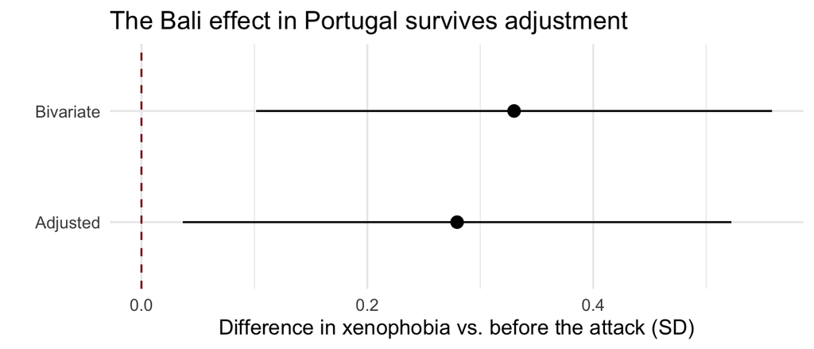

```r
plotdata <- bind_rows(
  tidy(ols_bi),          # Model 1: unadjusted
  tidy(ols_adj),         # Model 2: adjusted
  .id = "model"
) %>%
  filter(term == "treatAfter the attack") %>%   # Keep only the treatment effect
  mutate(model = case_when(model == "1" ~ "Bivariate",   # Model 1
                           model == "2" ~ "Adjusted"))   # Model 2

ggplot(plotdata, aes(x = estimate, y = model)) +
  geom_vline(xintercept = 0, colour = "#901A1E", linetype = "dashed") +
  geom_pointrange(aes(xmin = conf.low, xmax = conf.high)) +
  labs(
    title = "The Bali effect in Portugal survives adjustment",
    x = "Difference in xenophobia vs. before the attack (SD)",
    y = ""
  ) +
  theme_minimal(base_size = 13)
```

7. **Bonus, for the fast.** Age was only one of three controls. Fit a model with **age alone** (`anti_immi ~ treat + age`) and compare it to the full adjusted model. Which of the three controls is doing most of the work?

```r
ols_age <- lm_robust(anti_immi ~ treat + age, data = ESS, weights = pspwght)

modelsummary(
  list("Bivariate" = ols_bi, "+ age" = ols_age, "+ age, gender, employment" = ols_adj),
  coef_rename = c("treatAfter the attack" = "After the attack"),
  coef_omit = "^(?!treat)", # Show only the treatment effect
  stars = TRUE, gof_map = c("nobs"),
  output = "kableExtra"
)
```

[output not shown]

8. **Discuss with your neighbour.** Our estimate barely moved when we adjusted for three observed confounders. Work through these three steps:
   - Does a *small* change when adding controls make you **more** or **less** confident that the remaining estimate is causal? Why?
   - Name one confounder that is **not** in this data set but might plausibly affect both when someone was interviewed *and* how xenophobic they are.
   - If such a variable exists, can any regression on this data set fix it?
- A small change is **mildly reassuring**, not proof. It shows the observed confounders were not driving the result. But it says nothing about unobserved ones — a stable coefficient is consistent both with "no confounding left" and with "the confounding that remains is invisible".
- Plausible unobserved candidates: whether someone lives in a rural area or a city (affects both how easily interviewers reach them *and* their exposure to immigration), household composition, media diet, or how politically engaged they are.
- **No.** Multiple OLS can only close backdoor paths through variables that are *in the data*. That is precisely why Legewie needed the as-if-random timing in the first place — the design, not the regression, is what carries most of the credibility here.